# Homework 4 - Regression

### Dataset and Objective

```r
set.seed(315)
loanstats <-  read.csv(file = "LoanStats_securev1_2019Q4.csv",
                       stringsAsFactors = FALSE, header=TRUE, skip = 1)

# Turn percent into number
loanstats$int_rate <- gsub('%', '', loanstats$int_rate)
loanstats$int_rate <- as.numeric(loanstats$int_rate)

# Turn percent into number
loanstats$revol_util <- gsub('%', '', loanstats$revol_util)
loanstats$revol_util <- as.numeric(loanstats$revol_util)

factor_columns <- c(
  "home_ownership",
  "pymnt_plan",
  "purpose",
  "title",
  "grade",
  "term",
  "sub_grade"
  )

loanstats[factor_columns] <- lapply(loanstats[factor_columns], factor)
```

```r
summary(loanstats$int_rate)
```

```
##    Min. 1st Qu.  Median    Mean 3rd Qu.    Max.    NA's
##    6.00    8.81   12.40   13.20   16.95   28.80       2
```

My hypothesis is that the borrower’s debt-to-income ratio has a strong correlation with the interest rate on the loan since it reflects a borrower’s overall financial health. I think that as this ratio becomes larger, it means that it could be riskier to offer a loan to the borrower and that investors may want a higher premium for lending in the form of a higher interest rate.

```r
library(tidyverse)

loanstats <- loanstats %>% drop_na("dti", "int_rate")

cor(loanstats$dti, loanstats$int_rate)
```

```
## [1] 0.1015179
```

Another possible factor could be the amount of credit the borrower has used relative to the total amount of credit the borrower has.

```r
loanstats <- loanstats %>% drop_na("revol_util")

cor(loanstats$revol_util, loanstats$int_rate)
```

```
## [1] 0.2644278
```

Since `revol_util` has a stronger correlation with the loan interest rate than `dti`, I will try building a simple model with `revol_util` as the only variable. My goal is to solve for

$$a = \overline{y} - b\overline{x}$$
where $x$ is `revol_util` and $y$ is `int_rate`.

```r
library(caret)

trainIndex <- createDataPartition(loanstats$int_rate, p = 0.75, list=FALSE)
trainData <- loanstats[trainIndex,]
testData <- loanstats[-trainIndex,]

control <- trainControl(method="repeatedcv", number=3, repeats = 3, search = "grid")

fit.LR <- train(int_rate ~ revol_util, data=trainData, method="lm",
                metric="RMSE",  preProc=c("center", "scale"),
                trControl=control, tuneLength = 10)

summary(fit.LR)
```

```
##
## Call:
## lm(formula = .outcome ~ ., data = dat)
##
## Residuals:
##     Min      1Q  Median      3Q     Max
## -10.121  -3.958  -0.691   3.124  18.063
##
## Coefficients:
##             Estimate Std. Error t value Pr(>|t|)
## (Intercept) 13.20058    0.01617  816.48   <2e-16 ***
## revol_util   1.37155    0.01617   84.83   <2e-16 ***
## ---
## Signif. codes:  0 '***' 0.001 '**' 0.01 '*' 0.05 '.' 0.1 ' ' 1
##
## Residual standard error: 5.004 on 95787 degrees of freedom
## Multiple R-squared:  0.06988,    Adjusted R-squared:  0.06987
## F-statistic:  7197 on 1 and 95787 DF,  p-value: < 2.2e-16
```

```r
predictions <- predict(fit.LR, testData)

rmse <- RMSE(predictions, testData$int_rate)
rmse
```

```
## [1] 4.957138
```

```r
error.rate = rmse / mean(testData$int_rate)
error.rate
```

```
## [1] 0.376485
```

```r
R2(predictions, testData$int_rate)
```

```
## [1] 0.07006348
```

The value for R-squared is pretty close to 0. Ideally, this value is as close to 1 as possible. We therefore need to look for a model that achieves a value as close to 1 as possible, perhaps by finding one or multiple features that have a higher correlation with `int_rate`.

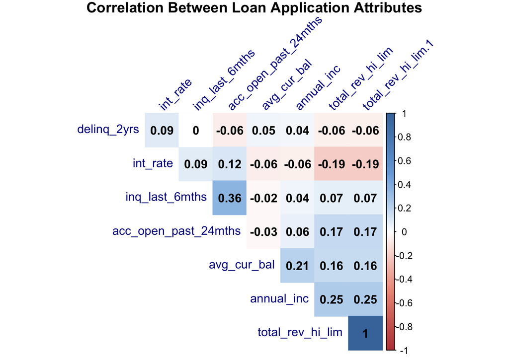

```r
library(Hmisc)
library(corrplot)

# Search for better fit
col <- colorRampPalette(c("#BB4444", "#EE9988", "#FFFFFF", "#77AADD", "#4477AA"))

features <- c(
  "annual_inc",
  "inq_last_6mths",
  "delinq_2yrs",
  "acc_open_past_24mths",
  "total_rev_hi_lim",
  "avg_cur_bal",
  "total_rev_hi_lim",
  "int_rate"
)
featureMatrix <- as.matrix(loanstats[features])
correlationR <- rcorr(featureMatrix)

correlationMatrix <- correlationR$r
pmat <- correlationR$P

corsig<-corrplot(correlationMatrix, method = "color", col = col(200),
   type = "upper", order = "hclust",
   addCoef.col = "black",
   tl.col = "darkblue", tl.srt = 45,
   p.mat = pmat, sig.level = 0.05, insig = "blank",
   diag = FALSE,
   title = "Correlation Between Loan Application Attributes",
   mar=c(0,0,1,0)
)
```

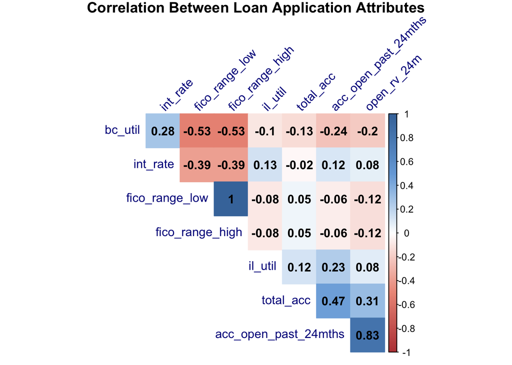

```r
# Continue looking for numerical features

features <- c(
  "acc_open_past_24mths",
  "fico_range_low",
  "fico_range_high",
  "bc_util",
  "open_rv_24m",
  "total_acc",
  "il_util",
  "int_rate"
)
featureMatrix <- as.matrix(loanstats[features] )
correlationR <- rcorr(featureMatrix)

correlationMatrix <- correlationR$r
pmat <- correlationR$P

corsig<-corrplot(correlationMatrix, method = "color", col = col(200),
   type = "upper", order = "hclust",
   addCoef.col = "black",
   tl.col = "darkblue", tl.srt = 45,
   p.mat = pmat, sig.level = 0.05, insig = "blank",
   diag = FALSE,
   title = "Correlation Between Loan Application Attributes",
   mar=c(0,0,1,0)
)
```

So far, none of the correlations between numerical features and interest rate look strong. Another idea is to look at nominal features to determine if adding a dummy variable to the model will help increase its accuracy:

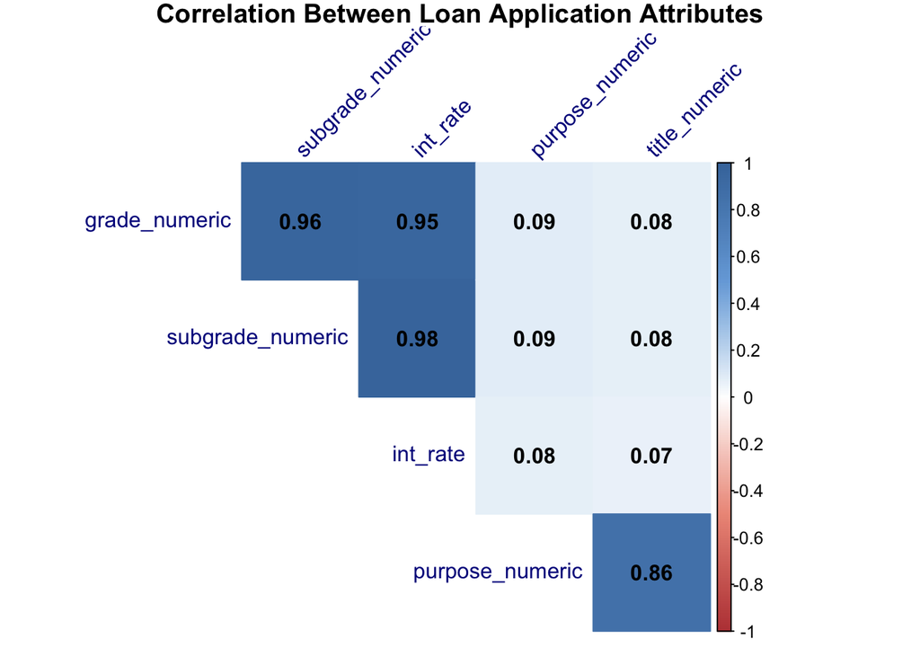

```r
# Try nominal features

loanstats$grade_numeric <- as.numeric(loanstats$grade)
loanstats$subgrade_numeric <- as.numeric(loanstats$sub_grade)
loanstats$purpose_numeric <- as.numeric(loanstats$purpose)
loanstats$title_numeric <- as.numeric(loanstats$title)

features <- c(
  "grade_numeric",
  "subgrade_numeric",
  "purpose_numeric",
  "title_numeric",
  "int_rate"
)

featureMatrix <- as.matrix(loanstats[features] )
correlationR <- rcorr(featureMatrix)

correlationMatrix <- correlationR$r
pmat <- correlationR$P

corsig<-corrplot(correlationMatrix, method = "color", col = col(200),
   type = "upper", order = "hclust",
   addCoef.col = "black",
   tl.col = "darkblue", tl.srt = 45,
   p.mat = pmat, sig.level = 0.05, insig = "blank",
   diag = FALSE,
   title = "Correlation Between Loan Application Attributes",
   mar=c(0,0,1,0)
)
```

```r
trainData <- loanstats[trainIndex,]
testData <- loanstats[-trainIndex,]

fit.LR <- train(int_rate ~ subgrade_numeric + revol_util, data=trainData, method="lm", metric="RMSE",  preProc=c("center", "scale"), trControl=control, tuneLength = 10)

summary(fit.LR)
```

```
##
## Call:
## lm(formula = .outcome ~ ., data = dat)
##
## Residuals:
##      Min       1Q   Median       3Q      Max
## -14.6139  -0.5909  -0.2799   0.2495   5.3466
##
## Coefficients:
##                   Estimate Std. Error  t value Pr(>|t|)
## (Intercept)      13.200578   0.003342 3949.346  < 2e-16 ***
## subgrade_numeric  5.081061   0.003469 1464.696  < 2e-16 ***
## revol_util        0.011776   0.003469    3.395 0.000688 ***
## ---
## Signif. codes:  0 '***' 0.001 '**' 0.01 '*' 0.05 '.' 0.1 ' ' 1
##
## Residual standard error: 1.034 on 95786 degrees of freedom
## Multiple R-squared:  0.9602, Adjusted R-squared:  0.9602
## F-statistic: 1.157e+06 on 2 and 95786 DF,  p-value: < 2.2e-16
```

R-squared is a lot closer to 1 now that I have added the sub_grade feature!

```r
predictions <- predict(fit.LR, testData)

R2(predictions, testData$int_rate)
```

```
## [1] 0.9613025
```